# Лабораточная работа №1

Izotov Ilya

26 сентября 2018 г

## Задание 1

1. Сгенерируйте 200 случайных значений из стандартного экспоненциального распределения и сохраните в вектор *exp.1*. Найдите среднее и стандартное отклонение из данных этого вектора.

```r
exp.1 <- rexp(n=200)
#Среднее
mean(exp.1)
```

```
## [1] 0.9931156
```

```r
#Стандартное отклонение:
sd(exp.1)
```

```
## [1] 0.8973676
```

2. Повторите, использовав следующие значения параметра λ: 0.1, 0.5, 5, 10, и сохраните результаты в векторы: *exp.0.1*, *exp.0.5*, *exp.5*, *exp.10*.

```r
#Для λ=0.1
exp.0.1 <- rexp(n=200, rate=0.1)
mean(exp.0.1); sd(exp.0.1)
```

```
## [1] 9.736856
```

```
## [1] 9.951799
```

```r
#Для λ=0.5
exp.0.5 <- rexp(n=200, rate=0.5)
mean(exp.0.5); sd(exp.0.5)
```

```
## [1] 2.057239
```

```
## [1] 2.160236
```

```r
#Для λ=5
exp.5 <- rexp(n=200, rate=5)
mean(exp.5); sd(exp.5)
```

```
## [1] 0.1981917
```

```
## [1] 0.2015944
```

```r
#Для λ=10
exp.10 <- rexp(n=200, rate=10)
mean(exp.10); sd(exp.10)
```

```
## [1] 0.08460056
```

```
## [1] 0.07626792
```

3. Функция `plot()` общая функция для визуализации данных. Функция `hist()` принимает данные и раскладывает их по корзинам. Чтобы использовать эти функции нужно для начала передать им данные, которые хотим визуализировать.
   1. Используйте функцию `hist()` для построения гистограммы полученного ранее стандартного распределения.

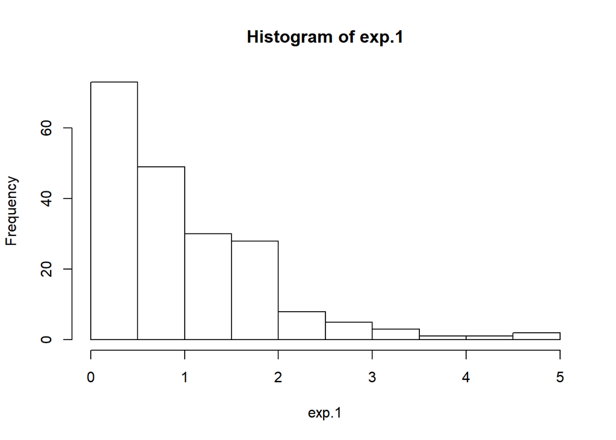

```r
hist(exp.1)
```

2. Используйте функцию `plot()` с тем же самым вектором для построения графика значений в порядке следования.

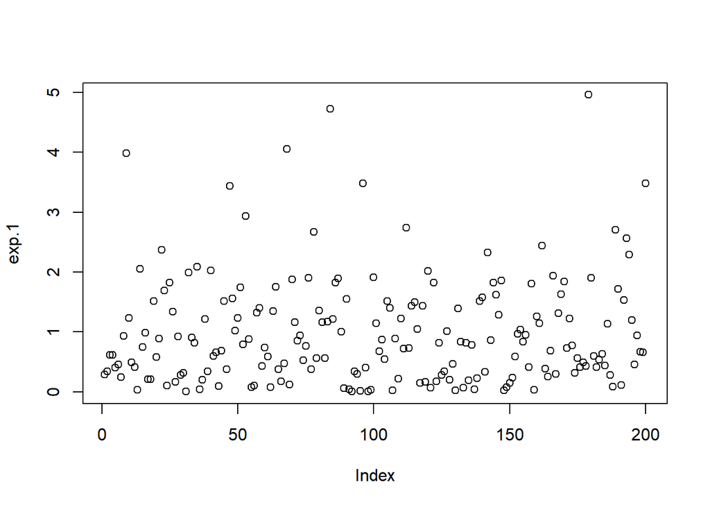

```r
plot(exp.1)
```

3. Используйте функцию `plot()` с любыми двумя полученными ранее векторами, чтобы получить диаграмму рассеяния ([scatterplot](https://www.mathsisfun.com/data/scatter-xy-plots.html)) этих векторов относительно друг друга.

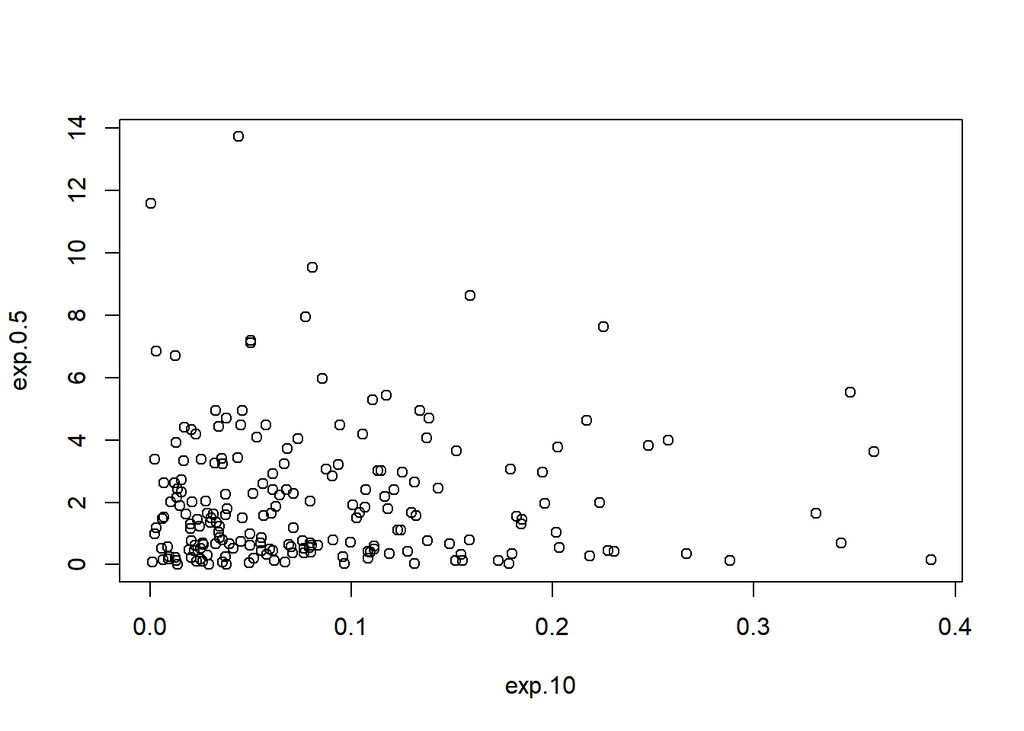

```r
plot(exp.10, exp.0.5)
```

4. Теперь сравним свойства всех наших векторов. Для начала создадим вектор, содержащий средние значения каждого из 5 полученных ранее распределений в порядке их создания. Полученный вектор сохраним в переменную *exp.means*. Далее необходимо создать следующие диаграммы рассеяния:
   1. Вектор с пятью средними относительно каждого из пяти векторов с различными значениями λ.

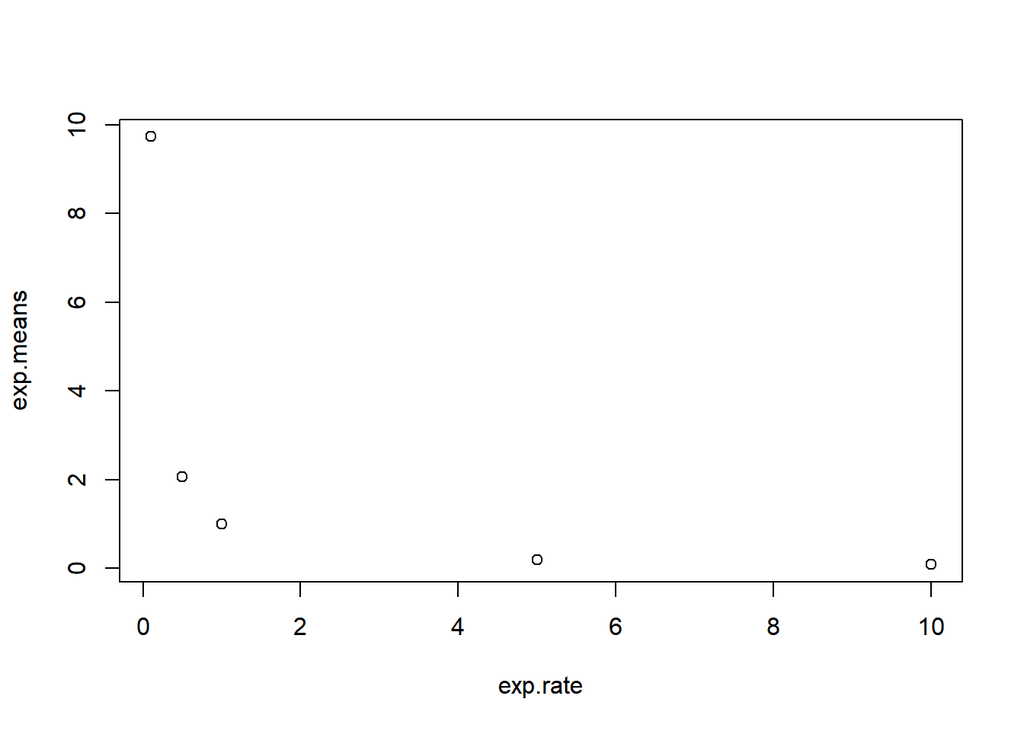

[output not shown]

```r
exp.means <- c(mean(exp.1), mean(exp.0.1), mean(exp.0.5), mean(exp.5), mean(exp.10))
exp.rate <- c(1, 0.1, 0.5, 5, 10)
plot(exp.rate, exp.means)
```

2. Вектор с пятью стандартными отклонениями относительно каждого из пяти векторов с различными значениями λ.

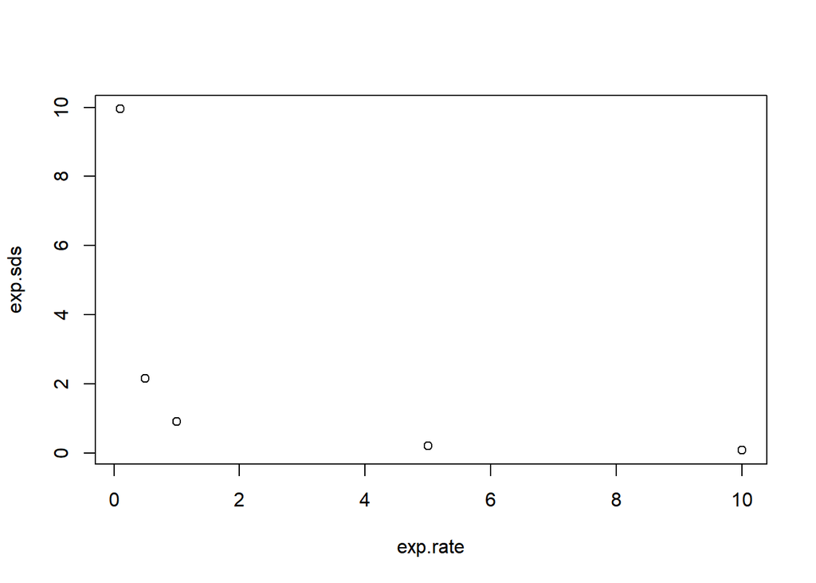

[output not shown]

```r
exp.sds <- c(sd(exp.1), sd(exp.0.1), sd(exp.0.5), sd(exp.5), sd(exp.10))
plot(exp.rate, exp.sds)
```

3. Вектор с пятью средними относительно вектора с пятью стандартными отклонениями.

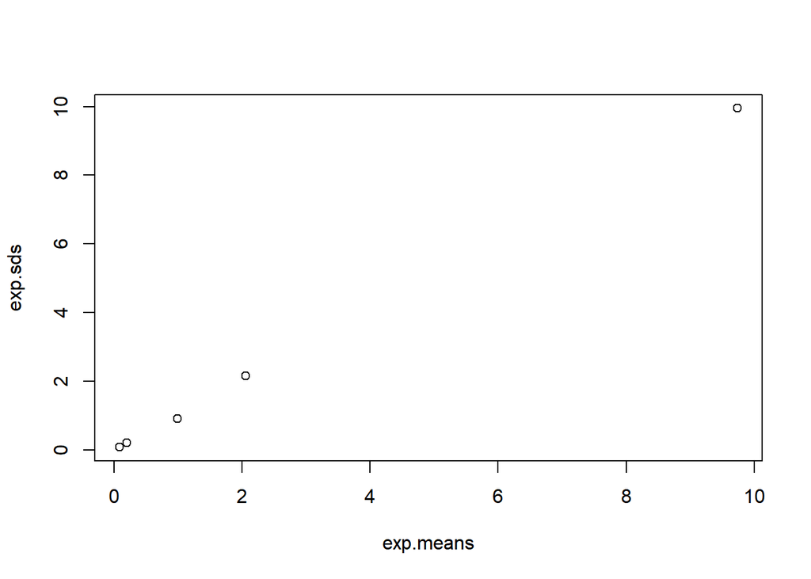

```
Вывод: видна прямая зависимость между средним значением и стандартным отклонением элементов вектора. Значения данной зависимости минимальны при λ=10 и возрастают при уменьшении λ до 0.1.
```

```r
plot(exp.means, exp.sds)
```

## Задание 2

R достаточно производителен, чтобы вычислять относительно большие объёмы данных.

- Для демонстрации сгенерируйте 1100000 (1 млн. 100 тысяч) чисел из стандартного экспоненциального распределения и сохраните их в вектор *huge.exp.1*. Получите среднее и стандартное отклонение.

```r
huge.exp.1 <- rexp(n = 1100000)
mean(huge.exp.1); sd(huge.exp.1)
```

```
## [1] 0.9998642
```

```
## [1] 0.9999136
```

- Получите гистограмму *huge.exp.1*. Она соответствует функции `1 - e:^(-x)`? Должна ли?

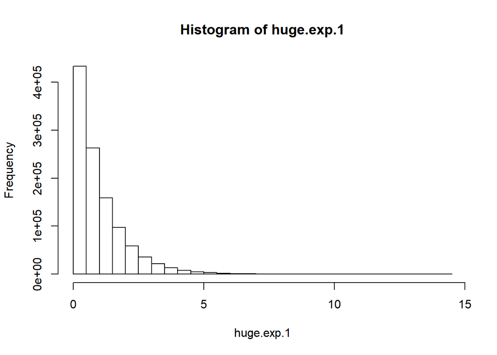

```r
hist(huge.exp.1)
```

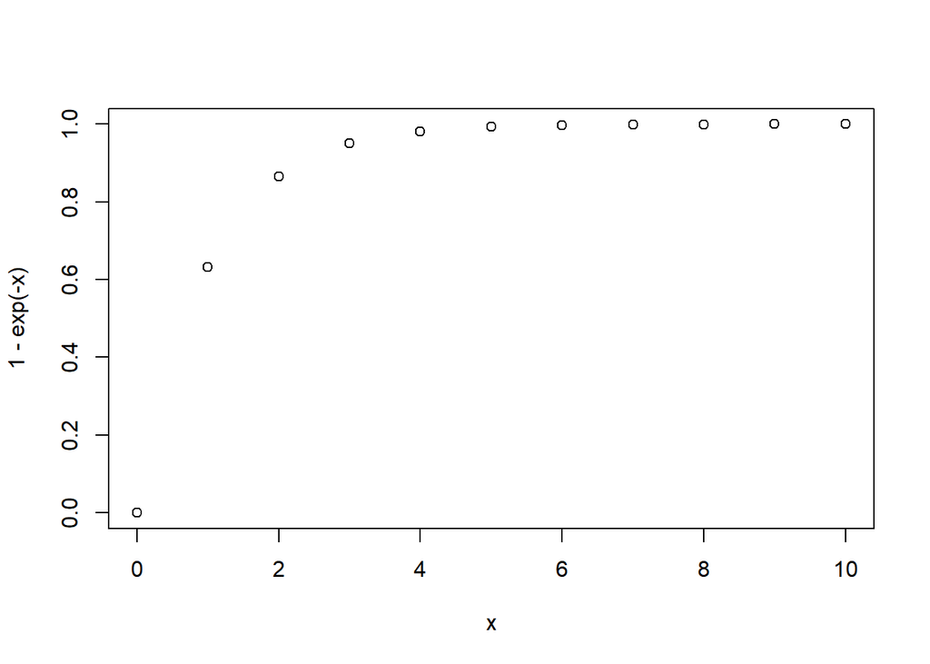

```
Вывод: видно, что гистограмма не соответствует функции 1 - e^(-x). И не должна ей соответствовать, поскольку соответствует e^(-x)
```

```r
x <- 0:10
plot(x,1-exp(-x))
```

- Получите среднее всех чисел из *huge.exp.1* строго больших 1. Для проверки выборки может потребоваться новый вектор.

```r
mean(huge.exp.1[huge.exp.1>1])
```

```
## [1] 2.00022
```

```r
min(huge.exp.1)
```

```
## [1] 1.778826e-07
```

```r
min(huge.exp.1[huge.exp.1>1])
```

```
## [1] 1.000003
```

- Получите матрицу *huge.exp.1.mat*, содержащую 1100 строк и 1000 колонок. Постройте гистограмму, использовав полученную матрицу. Что можно сказать о полученных данных?

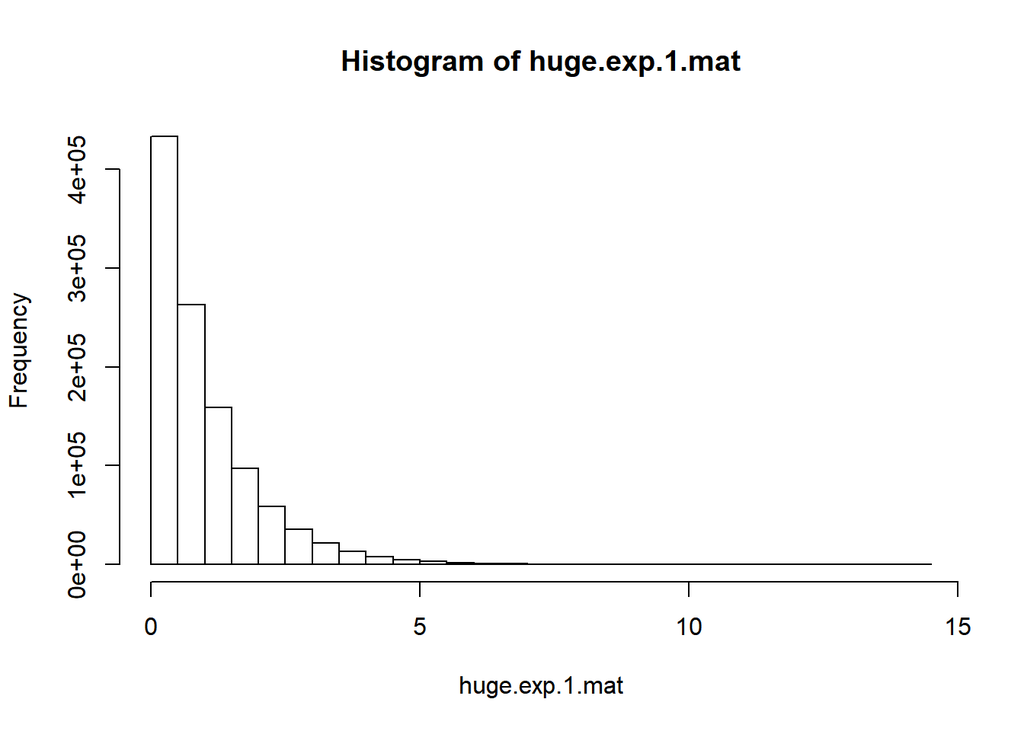

```
Вывод: данные размещены теперь не в векторе, а в матрице 1100 на 1000, гистограмма не изменилась, поскольку данные те же самые.
```

```r
huge.exp.1.mat <- matrix(huge.exp.1, nrow = 1100, ncol = 1000)
hist(huge.exp.1.mat)
```

- Рассчитайте среднее 137-й колонки из *huge.exp.1.mat*.

```r
mean(huge.exp.1.mat[,137])
```

```
## [1] 0.9948329
```

- Найдите среднее всех 1000 колонок и сохраните их в вектор. Отобразите диаграмму средних значений колонок. Объясните почему форма диаграммы отличается от виденных ранее.

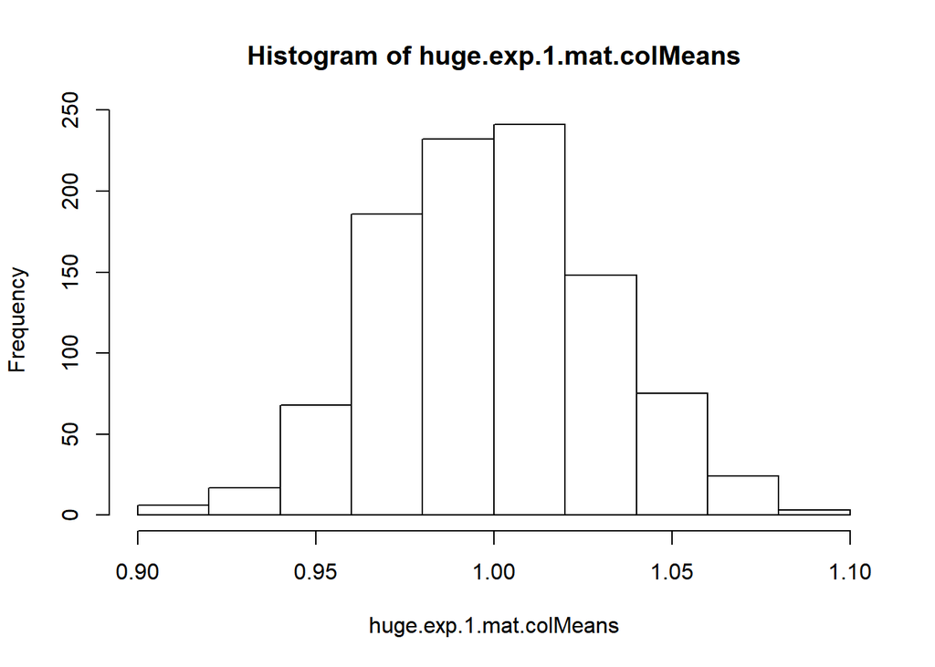

```
Вывод: диаграмма отличается от полученной ранее, поскольку в ней отображены средние значения. Средние значения экспоненциального распределения будут стремиться к нормальному распределению.
```

```r
huge.exp.1.mat.colMeans <- colMeans(huge.exp.1.mat)
hist(huge.exp.1.mat.colMeans)
```

- Рассчитайте квадрат каждого значения из *huge.exp.1* и найдите среднее и стандартное отклонение полученного вектора квадратов. Объясните отличие от соответствующих показателей вектора *huge.exp.1*. Вам может помочь формула, по которой R рассчитывает стандартное отклонение: `sqrt(sum((x - mean(x))^2) / (n - 1))`.

```r
huge.exp.1.square <- huge.exp.1^2
mean(huge.exp.1.square); sd(huge.exp.1.square)
```

```
## [1] 1.999555
```

```
## [1] 4.464952
```

[output not shown]